# Homework_3_Solal_Danan

## Homework 3

**Exercice 5.5**

```python
import pandas as pd
import numpy as np
import matplotlib.pyplot as plt
from scipy.stats import multivariate_normal
```

```python
alpha = 0.01
beta = 1
```

```python
df = pd.read_csv("year-sunspots-republicans.csv")
df.head()
```

|  | Year | Sunspot_Count | Republican_Count |
| --- | --- | --- | --- |
| 0 | 1960 | 112.3 | 36 |
| 1 | 1962 | 37.6 | 34 |
| 2 | 1964 | 10.2 | 32 |
| 3 | 1966 | 47.0 | 36 |
| 4 | 1968 | 105.9 | 43 |

Recall that the numbers in the Year column are large (between 1960 and 2006), especially when raised to various powers. To avoid numerical instability due to ill-conditioned matrices in most numerical computing systems, we will scale the data first: specifically, we will scale all “year” inputs by subtracting 1960 and then dividing by 40.

### 1. Implement these procedures to obtain new features (you can use the function you implement for the last homework Exercise 2.6). In the sequel, we only use these new features.

```python
df["Year"] = (df["Year"]-1960)/40
df.head()
```

|  | Year | Sunspot_Count | Republican_Count |
| --- | --- | --- | --- |
| 0 | 0.00 | 112.3 | 36 |
| 1 | 0.05 | 37.6 | 34 |
| 2 | 0.10 | 10.2 | 32 |
| 3 | 0.15 | 47.0 | 36 |
| 4 | 0.20 | 105.9 | 43 |

```python
# Function that create an array of polynomial feature
def basis_a(x):
    n = len(x)
    max_degree=5
    # Initialize an array to store the polynomial features
    features = np.zeros((n, max_degree +1 ))

    # Populate the array with polynomial features
    for j in range(max_degree+1):
        features[:, j] = x ** j

    #Returns: np.array: of shape (n, max_degree+1 )
    return features



# Function that create an array of exponential feature
def basis_b(x):
    n = len(x)
    mu=np.arange(0,51,5)

    # Initialize an array to store the polynomial features
    features = np.ones((n, len(mu)+1))

    for j in range(len(mu)):
        features[:, j+1] = np.exp(-((40*x - mu[j])**2)/25)

    #Returns: np.array: of shape (n, len(mu)+1)
    return features



# Function that create an array of cosinus feature
def basis_c(x):
    n = len(x)
    a=np.arange(1,6)

    # Initialize an array to store the polynomial features
    features = np.ones((n, len(a)+1))

    for j in range(len(a)):
        features[:, j+1] = np.cos(x/a[j])

    #Returns: np.array: of shape (n, len(a)+1)
    return features



# Function that create an array of cosinus feature
def basis_d(x):
    n = len(x)
    a=np.arange(1,26)

    # Initialize an array to store the polynomial features
    features = np.ones((n, len(a)+1))

    for j in range(len(a)):
        features[:, j+1] = np.cos(x/a[j])

    #Returns: np.array: of shape (n, len(a)+1)
    return features
```

### 2. Plot the data and the Bayesian predictor for each of the following sets of basis functions, and include the generated plot as an image in your submission. You will therefore make 4 total plots:

**For each set of basis functions, compute the posterior standard deviation x′ 7→ σN (x′) and illustrate the predictive uncertainty by plotting a shaded region, that spans σN (x′) either side of yˆD(x′). Again, you therefore make 4 total plots.**

```python
# Returns the squared distance between the predictions and the ground truth.

def compute_averaged_squared_error(X, w, y):
    """
    Given the matrix of features, the parameters of the linear regression and the vector of targets,
    returns the squared distance between the predictions and the ground truth.
    """
    n = len(y)
    error = np.linalg.norm(y - X@w, 2)**2

    # Returns: error (float): the averaged squared distance between the predictions and the ground truth.
    return error/n



def posterior_distribution(X, y, alpha, beta):
    """
    Given a few precision on the prior and the error, we compute the posterior mean and variance
    Posterior distribution of w given the observed data
    """
    Sigma_posterior = np.linalg.inv(alpha*np.eye(X.shape[1]) + beta*X.T@X)  # Posterior covariance
    mean_posterior = Sigma_posterior @ (X.T@y) * beta

    return mean_posterior, Sigma_posterior



def bayesian_regression_plot(x, y, fct, alpha = 0.01, beta = 1, uncertainty=True):

    c = ["basis_a","basis_b","basis_c","basis_d"]
    if fct not in c:
        raise ValueError("Choose a function between basis_a, basis_b, basis_c, and basis_d")

    Phi = eval(fct +"(x)")

    #Get the posterior mean in order to compute the estimator
    mean_posterior, Sigma_posterior = posterior_distribution(Phi, y, alpha, beta)

    #Compute the bayesian estimator
    y_bayesian_estimator = Phi@mean_posterior

    #Compute the MSE
    mse = compute_averaged_squared_error(Phi, mean_posterior, y)

    plt.plot(x, y, 'b.', label='Data')
    plt.plot(x, y_bayesian_estimator, 'r', label='Regression line')
    plt.title('Bayesian Regression for basis function '+ fct)


    if uncertainty:
        # Compute the standard deviation of the predictive distribution for a new input x_new
        variance_predictive = 1/beta +np.diag(Phi@Sigma_posterior@Phi.T)
        std_dev_predictive = np.sqrt(variance_predictive)

        #Shaded region
        plt.fill_between(x, y_bayesian_estimator - std_dev_predictive,
                 y_bayesian_estimator + std_dev_predictive, color='g', alpha=0.2, label='95% Predictive Interval')

    plt.legend()
    plt.show()
    print("The mean square error for basis function " + fct + " is MSE=" + str(round(mse, 3)))
```

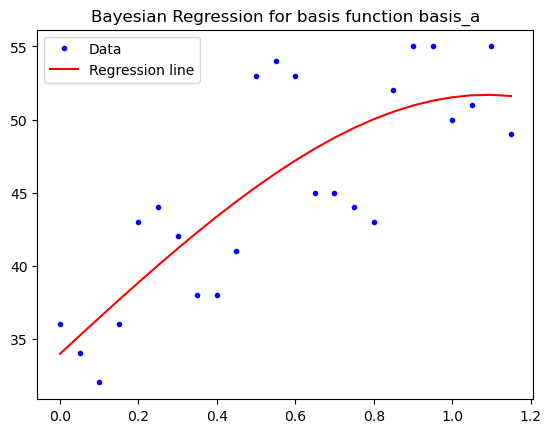

```
The mean square error for basis function basis_a is MSE=17.74
```

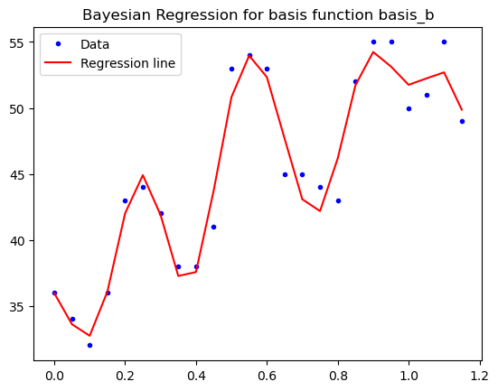

```
The mean square error for basis function basis_b is MSE=2.294
```

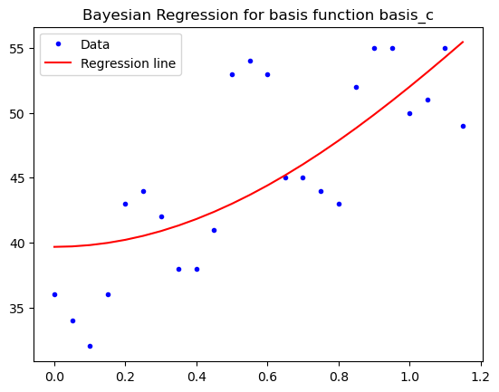

```
The mean square error for basis function basis_c is MSE=24.552
```

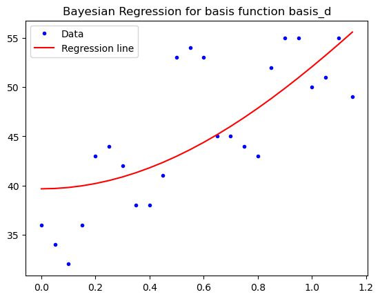

```
The mean square error for basis function basis_d is MSE=24.649
```

```python
# Plot of the data and the Bayesian predictor for each of the basis functions

bayesian_regression_plot(df["Year"], df["Republican_Count"], "basis_a", uncertainty=False)
bayesian_regression_plot(df["Year"], df["Republican_Count"], "basis_b", uncertainty=False)
bayesian_regression_plot(df["Year"], df["Republican_Count"], "basis_c", uncertainty=False)
bayesian_regression_plot(df["Year"], df["Republican_Count"], "basis_d", uncertainty=False)
```

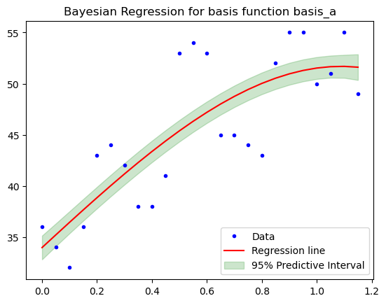

```
The mean square error for basis function basis_a is MSE=17.74
```

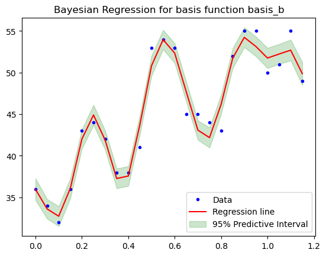

```
The mean square error for basis function basis_b is MSE=2.294
```

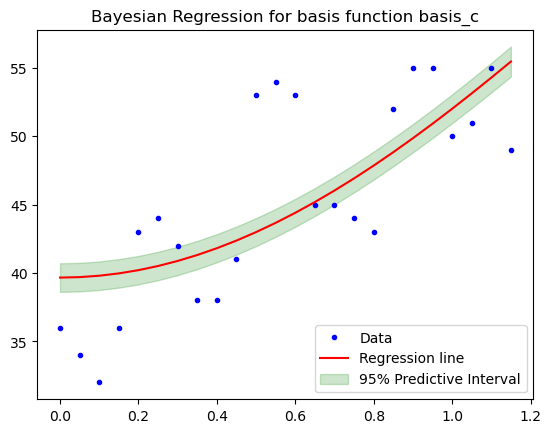

```
The mean square error for basis function basis_c is MSE=24.552
```

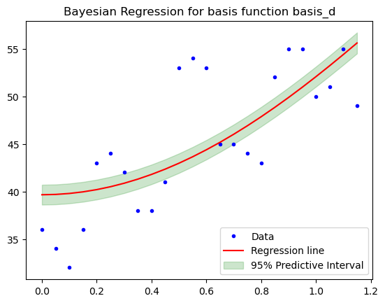

```
The mean square error for basis function basis_d is MSE=24.649
```

```python
# Plot of the data and the Bayesian predictor for each of the basis functions with the 95% Predictive Interval


bayesian_regression_plot(df["Year"], df["Republican_Count"], "basis_a")
bayesian_regression_plot(df["Year"], df["Republican_Count"], "basis_b")
bayesian_regression_plot(df["Year"], df["Republican_Count"], "basis_c")
bayesian_regression_plot(df["Year"], df["Republican_Count"], "basis_d")
```

### 3- Repeat the same exact process as above but for Number of Sunspots (x-axis) v. Number of Republicans in the Senate (y-axis).

**Here, to avoid numerical instability with numbers in the Sunspot Count column, we will also scale the data first by dividing all “sunspot count” inputs by 20. In addition, only use data from before 1985, and only use basis functions (a), (c), and (d) – ignore basis (b). You will therefore make 3 total plots. For each plot make sure to also include the train error.**

```python
df_q3 = df.sort_values("Sunspot_Count")
df_q3 = df_q3[df_q3["Year"] <= (1985-1960)/40]
df_q3["Sunspot_Count"] = df_q3["Sunspot_Count"]/20
df_q3.head()
```

|  | Year | Sunspot_Count | Republican_Count |
| --- | --- | --- | --- |
| 2 | 0.10 | 0.510 | 32 |
| 8 | 0.40 | 0.630 | 38 |
| 7 | 0.35 | 1.725 | 38 |
| 1 | 0.05 | 1.880 | 34 |
| 12 | 0.60 | 2.295 | 53 |

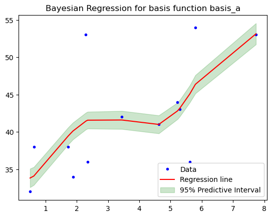

```
The mean square error for basis function basis_a is MSE=28.048
```

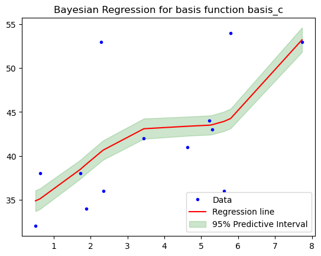

```
The mean square error for basis function basis_c is MSE=29.674
```

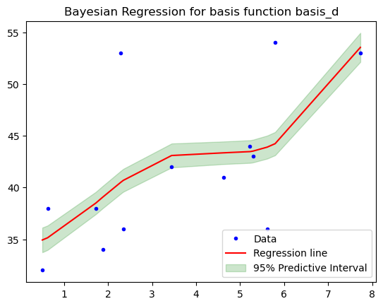

```
The mean square error for basis function basis_d is MSE=29.679
```

```python
# Plot of the data and the Bayesian predictor for each of the basis functions with the 95% Predictive Interval


bayesian_regression_plot(df_q3["Sunspot_Count"], df_q3["Republican_Count"], "basis_a")
bayesian_regression_plot(df_q3["Sunspot_Count"], df_q3["Republican_Count"], "basis_c")
bayesian_regression_plot(df_q3["Sunspot_Count"], df_q3["Republican_Count"], "basis_d")
```

### 4. Compute the marginal likelihood (or normalizing constant) for the the three bases (a, c, d).

```python
def marginal_likelihood(x, y, fct, alpha = 0.01, beta = 1):

    c = ["basis_a","basis_b","basis_c","basis_d"]
    if fct not in c:
        raise ValueError("Choose a function between basis_a, basis_b, basis_c, and basis_d")

    Phi = eval(fct + "(x)")

    posterior_mean, posterior_variance = posterior_distribution(Phi, y, alpha, beta)

    cst = (     np.log(alpha) * (Phi.shape[1]) / 2 + (np.log(beta) - np.log(2 * np.pi)) * (Phi.shape[0] / 2)
              + np.log(np.linalg.det(posterior_variance) + 1e-10) / 2    )

    lml = cst - (0.5*beta*(np.linalg.norm(y-Phi@posterior_mean,2)**2)
                + 0.5*alpha*(np.linalg.norm(posterior_mean)**2))

    return np.exp(lml)
```

```python
print(marginal_likelihood(df_q3["Sunspot_Count"], df_q3["Republican_Count"], "basis_a"))
print(marginal_likelihood(df_q3["Sunspot_Count"], df_q3["Republican_Count"], "basis_c"))
print(marginal_likelihood(df_q3["Sunspot_Count"], df_q3["Republican_Count"], "basis_d"))
```

```
2.758420086875149e-99
8.53796041090253e-100
2.1882108311927966e-96
```

**The marginal likelihood is too small and close so 0 so it is more usefull to use the log lieklihood**

```python
def log_marginal_likelihood(x, y, fct, alpha = 0.01, beta = 1):

    c = ["basis_a","basis_b","basis_c","basis_d"]
    if fct not in c:
        raise ValueError("Choose a function between basis_a, basis_b, basis_c, and basis_d")

    Phi = eval(fct + "(x)")

    posterior_mean, posterior_variance = posterior_distribution(Phi, y, alpha, beta)

    cst = (
          np.log(alpha) * (Phi.shape[1]) / 2 + (np.log(beta) - np.log(2 * np.pi)) * (Phi.shape[0] / 2)
          + np.log(np.linalg.det(posterior_variance) + 1e-10) / 2
    )

    lml = cst - (
        0.5*beta*(np.linalg.norm(y-Phi@posterior_mean,2)**2) + 0.5*alpha*(np.linalg.norm(posterior_mean)**2))



    return lml
```

```python
lml_a = log_marginal_likelihood(df_q3["Sunspot_Count"], df_q3["Republican_Count"], "basis_a")
lml_c = log_marginal_likelihood(df_q3["Sunspot_Count"], df_q3["Republican_Count"], "basis_c")
lml_d = log_marginal_likelihood(df_q3["Sunspot_Count"], df_q3["Republican_Count"], "basis_d")


print( f"the log marginal likelihood for the model with basis_a is: {lml_a: .3f}")
print( f"the log marginal likelihood for the model with basis_c is: {lml_c: .3f}")
print( f"the log marginal likelihood for the model with basis_d is: {lml_d: .3f}")
```

```
the log marginal likelihood for the model with basis_a is: -226.941
the log marginal likelihood for the model with basis_c is: -228.114
the log marginal likelihood for the model with basis_d is: -220.265
```

### 5. Deduce from your last answer, which of the three bases (a, c, d) provided the ”best” fit from a Bayesian perspective?

From a Bayesian perspective, the "best" fit is the model with the basis_d function as the log marginal likelihood is higher than for the other basis function

### 6. Discuss on the choice of $\alpha$ and $\sigma$ .

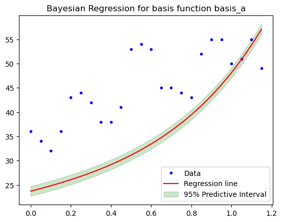

```
The mean square error for basis function basis_a is MSE=144.791
alpha =  10
```

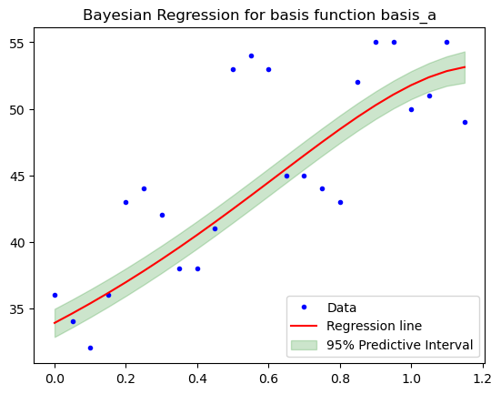

```
The mean square error for basis function basis_a is MSE=21.767
alpha =  1
```

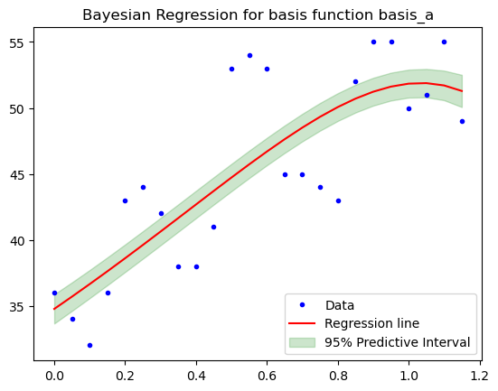

```
The mean square error for basis function basis_a is MSE=18.064
alpha =  0.1
```

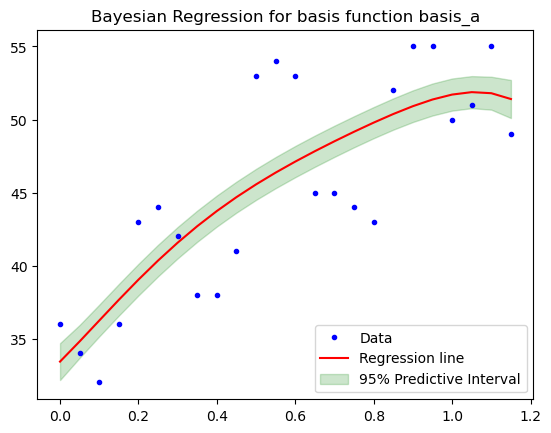

```
The mean square error for basis function basis_a is MSE=17.471
alpha =  0.0001
```

```python
alpha = [10, 1, 0.1, 0.0001]

for a in alpha:
    bayesian_regression_plot(df["Year"], df["Republican_Count"], "basis_a", alpha=a)
    print("alpha = " , a)
```

$\alpha$ represents the inverse of the variance of our prior. Then, the smaller $\alpha$ is, the bigger our uncertainty about our prior is. In this case, our posterior distrubution will rely more on the data than on our prior.

More precisely, we can see in the formulas for the posterior variance, for small alpha will give posterior variance matrix $S_n$ bigger.

Here, as $\alpha$ decrease, our MSE deacrease and our model is more precise

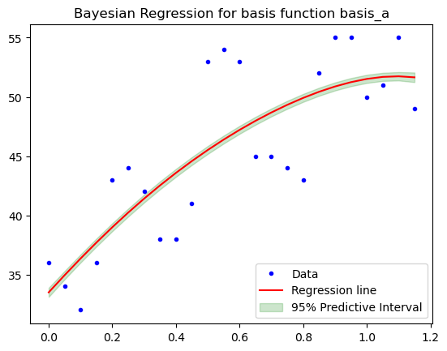

```
The mean square error for basis function basis_a is MSE=17.667
beta =  10
```

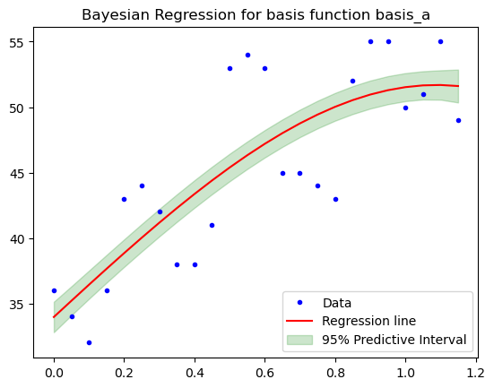

```
The mean square error for basis function basis_a is MSE=17.74
beta =  1
```

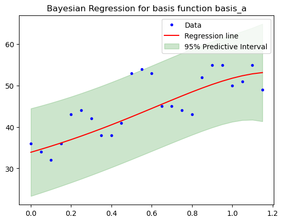

```
The mean square error for basis function basis_a is MSE=21.767
beta =  0.01
```

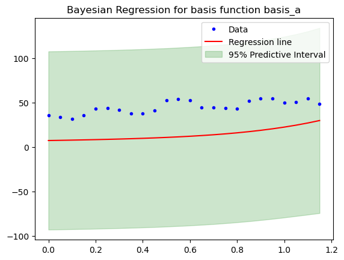

```
The mean square error for basis function basis_a is MSE=996.999
beta =  0.0001
```

```python
beta = [10, 1, 0.01, 0.0001]

for a in beta:
    bayesian_regression_plot(df["Year"], df["Republican_Count"], "basis_a", beta=a)
    print("beta = " , a)
```

$\beta = 1/\sigma^2$

$ \sigma $ represents the noise on the data. The bigger $ \sigma $ is, the bigger will be the uncertainty linked to the data. In this case, the posterior mean for w will be close to the prior mean, in this case 0.

Conversely, when $\beta$ is big, the model is more precise and take well into account the data